# GraphDB

Ollin Demian

3 de noviembre de 2017

# Bases de Datos Orientadas a Grafos

## ¿Qué son los grafos o redes?

Para comprender la motivación de este tipo de base de datos y las redes en general hay que ponernos un poco en contexto.

Los orígenes del método científico moderno se remontan tan lejos como el siglo XVII cuando importantes figuras como Descartes y Newton desarrollaron sus metodologías en base a un pensamiento *reduccionista*, esto quiere decir que la meta principal de la ciencia era llegar a la explicación más mínima de todos los fenómenos en términos de física fundamental.

> El reduccionismo es la cosa más natural de entender en el mundo. Simplemente es la creencia de que “un todo puede ser entendido completamente si tan solo entiendes sus partes, y la naturaleza de su ‘suma’”. Nadie puede rechazar el reduccionismo con el hemisferio izquierdo de su cerebro.

> **Douglas Höfstadter**, *Gödel, Escher, Bach: an Eternal Golden Braid*.

Comprender el reduccionismo es realmente sencillo pues es la escuela de pensamiento que nos han enseñado desde la primaria y está representada por las siguientes palabras de Descartes: “dividir todas las dificultades que se encuentran bajo examinación en el mayor número de partes posible y tantas como sean necesarias para resolverlas de la mejor manera” y " conducir mis pensamientos en en un cierto orden, empezando con lo más simple y fácil de entender de los objetos, y gradualmente ascender paso a paso al conocimiento más complejo“.

Pero no por ser el enfoque más usado quiere decir que sea el único ni el mejor. Fue Aristóteles, quien vivió en el siglo IV a.C., quien pustuló que El todo es más que la suma de sus partes dando naciemiento a otra importante corriente de pensamiento, el *holismo*. Este último se refiere a que no podemos entender los fenómenos por medio de sumar los comportamientos individuales de sus componentes sino que hay que tomar en consideración tanto a dichas componentes como a sus interacciones y sus propiedades. Este pensamiento ha permeado en las últimas dos décadas a distintas ramas científicas como la economía, la biología, sociología, medicina, ciencias cognitivas e incluso la física. Los sistemas representados en dichas áreas son llamados en conjunto *sistemas complejos*. Definir complejidad no es de ninguna manera una tarea sencilla aunque actualmente los científicos y filósofos están llegando al acuerdo de tomarlo como una medida de información. Es decir, un sistema será más complejo cuanta más información posea. Con una definición así podemos darnos cuenta de la complejidad que guardan por ejemplo; el genoma humano, el sistema nervioso, internet y más específico de nuestro interés, los sistemas sociales.

Una de las ramas de las ciencias de la complejidad que más auge ha tenido por el nivel de resultados y portabilidad a distintos problemas es la ciencia de redes (network science). Una red es una representación simplificada que reduce un sistema a una estructura abstracta que captura sólo las bases de los patrones de conexión entre elementos. Las conexiones, que llamaremos *aristas*, pueden representar cualquier tipo de interacción entre individuos como lo es la amistad, comunicación, la pertenencia a un programa social, etc. y esto sólo dependerá de las preguntas que estemos interesados en resolver.

> Nunca entenderemos los sistemas complejos a menos que desarrollemos un profundo entendimiento de las redes detrás de ellos.

> **Albert-László Barabási**, *Network Science*.

## ¿Qué es una base de datos orientada a grafos y por qué la necesito?

Así como las componentes de un sistema, es difícil entender nuestros datos si no es por medio de relaciones y como el mundo avanza también lo hace la necesidad por estar *conectado* como individuo en una sociedad o por medio del internet de las cosas (IoT) y de la información para tener un acceso ordenado a la misma.

Cuando se usa algún tipo de base de datos **SQL** y necesitamos buscar una relación entre las columnas de nuestros datos usualmente se utilizan los llamados *JOIN* que hace una búsqueda exhaustiva por parejas de columnas de orden $N*(N-1) \sim N^2$ siendo $N$ el número de renglones (observaciones) en nuestra base de datos mientras que si pensamos en una base de datos orientada a grafos el costo máximo de esta operación será de $N*(N-1)/2$ si la red no contempla direcciones o $N*(N-1)$ si sí lo hace, pues este es el mayor número de conexiones posibles dentro de una red aunque la palabra *máximo* es clave pues será la cota superior y usualmente el costo será menor. En un mundo donde todos los días escuchamos sobre las *redes* sociales, la *red* de la telefonía celular, el interNET, las *redes* criminales, las *redes* de distribución, etc. es difícil no pensar en que existe una arquitectura de sistemas que está dominando el mundo actual, así que poder organizar, administrar y acceder a los datos en su forma fundamental es realmente algo necesario, por claridad y costo. Es por eso que este tipo de base de datos son utilizadas para un gran número de tareas como detección de fraude, sistemas de recomendación, manejo de identidades y redes sociales.

## ¿Cómo adoptar una base de datos orientada a grafos?

Por la forma en la que hemos aprendido a pensar y a computar la información, la mayor parte de esta sólo es accesible por medio de tablas por lo cuál la parte más importante y fundamental de la adopción a un esquema en red es la interiorización de este tipo de abstracción. Pongamos un ejemplo:

En Mayo de 1933, un psiquiatra Rumano llamado Jacob Moreno formuló por primera vez la entidad que al día de hoy conocemos como red social. Hizo una encuesta en una escuela primaria y preguntó a cada niño quién de los otros era su amigo, por lo que en un esquema tabular tradicional obtendría algo del estilo:

| Niño | Amigos | Niño |
| --- | --- | --- |
| 1 | Sí | 2 |
| 1 | Sí | 3 |
| 1 | No | 4 |
| . | . | . |
| . | . | . |
| . | . | . |
| 28 | Sí | 26 |
| 28 | No | 17 |

Lo que dificultaría mucho hacer inferencias y observar fenómenos importantes a simple vista. Pero él desarrolló algo a lo que llamó *sociogramas* como el que vemos a continuación:

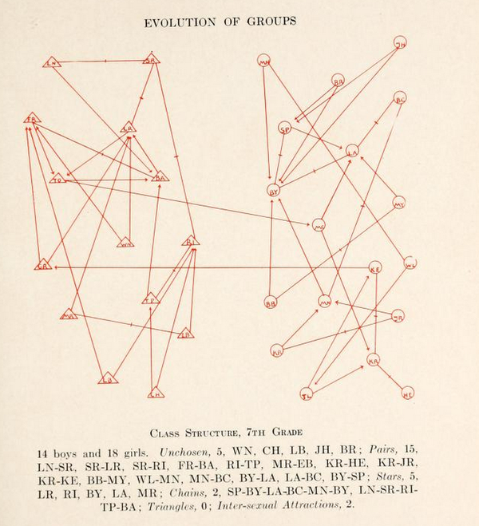

A simple vista podemos observar una segregación y al inspeccionar vemos que es de niñas que son representadas por los círculos y niños por triángulos. De esta manera podemos ver cómo el adoptar una arquitectura de grafo nos permite vislumbrar el fenómeno colectivo generado por las interacciones locales. Comencemos con la importación a una base de datos orientada a grafos por lo que a los agentes les llamaremos nodos (nodes) y a las interacciones aristas (edges). La base de datos que vamos a utilizar se llama Neo4j y existe una gran cantidad de tutoriales en internet de cómo utilizarlo, por lo que tocaremos puntos muy poco documentados pero escenciales cuando la cantidad de datos es muy grande y cuando además queremos gestionar distintas bases en el mismo sistema.

### ¿Por qué Neo4j?

Es la base de datos orientada a grafos más popular del mundo y cuenta con una vasta documentación pues su comunidad es enorme. Tiene una interfaz gráfica que la hace muy sencilla de aprender y usar, cuenta con una versión gratuita pero es ampliamente escalable. Recientemente se lanzó la versión 3.3.0 que dice ser 55% más rápida en transacciones por segundo por core que la versión anterior además de contar con nueva y mejorada seguridad y herramientas de analisis y mejor conexión a lenguajes de programación. Todo esto es relevante para cuestiones de seguridad de nuestros datos y la amabilidad en el proceso de transformación y análisis de los mismos.

[figure not shown]

### El uso de contenedores

Actualmente el uso de servicio de contenedores de aplicaciones se encuentra en crecimiento y está muy extendido. La adopción de esta tecnología tiene grandes implicaciones como la portabilidad de las aplicaciones entre computadoras pues al estar contenidos en un paquete, cuentan por sí mismos con todas sus dependencias y un gran ejemplo son los nuevos paquetes *Snap* para Linux que permiten la instalación unificada de programas en cualquier distribución. Otro servicio de contenedores ampliamente utilizado es *Docker*

[figure not shown]

el cual utilizaremos no sólo para facilidad en portabilidad sino porque también nos permite cambiar los puertos de conexión haciendo posible de forma relativamente sencilla montar conexiones a distintas bases de datos al mismo tiempo.

### Importación de datos *grandes*

Si bien el hecho de que existan grandes cantidades de datos para analizar es emocionante, la forma en la que podemos manejarlos muchas veces supera las capacidades de nuestra computadora personal. Estamos acostumbrados a guardar nuestros documentos en el disco duro de la PC y cuando requerimos manipularlos los abrimos con algún programa como *Excel* o lenguaje de programación como *Python*, al hacer esto normalmente se genera una copia de los datos en la RAM de nuestra computadora, que en la mayoría de los casos no supera los 8Gb de capacidad. Entonces, ¿Cómo manipulamos archivos de 10, 20, 80Gb o más? en algunas ocaciones podemos llegar a obtener archivos que superan la capacidad de nuestro disco duro. Podemos comprar muchos discos duros o podemos mudarnos a la llamada *nube* donde podemos disponer de todo el espacio y poder de computo que podamos llegar a necesitar. En esta nube contamos con discos duros en los que podemos guardar archivos realmente grandes por una cantidad de dinero muy pequeña en comparación con los costos de hardware. La oferta de servicios en la nube está creciendo y se pueden encontrar muchos provedores que se ajusten a nuestras necesidades, en esta ocasión se realizará con Amazon Web Services (AWS) que es el servicio de la empresa Amazon, actual lider mundial en el rubro. Los servicios de AWS que utilizaremos serán Elastic Cloud Computing (EC2) y Simple Storage Service (S3), la primera para procesar y la segunda para guardar. Sería un gasto innecesario de la limitada memoria de nuestra computadora si bajáramos los datos de S3 para modificarlos, en lugar de esto lo que podemos hacer es modificarlos mientras los vamos leyendo. Nuestras tablas iniciales cuentan con 20 columnas que incluyen: * Código de dependencia * Origen de los recursos * ID de la administración * Código del programa * Código del padrón * Año del pago * Periodo del pago * Nombre del beneficiario * Fecha de nacimiento del beneficiario * Sexo * Mes de pago * Identificador del beneficiario * Importe del pago * Clave de la entidad * Clave del municipio * Clave de la localidad * Indicador de si el beneficiario es el titular * Clave del beneficio * Edad * Categoría de edad

De esta manera lo que tenemos son CSV (Comma Separeted Values) que en total pesan al rededor de 80Gb y utilizaremos *Python* para leerlos línea por línea y así poder procesarlos. Por ejemplo, si queremos obtener los valores únicos de una columna en particular:

```python
import smart_open
import csv

FILENAME = 's3://nombre-bucket/archivo.csv'

with smart_open.smart_open(FILENAME,'r') as r:
    f = (line.decode('utf-8') for line in r)
    reader = csv.reader(f, delimiter='|')
    output = []
    seen = set()
    for row in reader:
        if row[1] not in seen:
            seen.add(row[1])
            output.append(row[1])
    print(output)
```

Lo que hace el script anterior es: * Abrir una conexión a nuestro archivo en S3 * Decodificar línea por línea de bytes a Strings (Cadenas de caracteres) * Separarlo por columnas de acuerdo al separador del CSV, en este caso ‘|’ * Y por cada línea si el valor de la columna no se ha visto antes entonces guardarlo en un arreglo * Imprimir el arreglo final

Lo anterior nos permite poder leer y modificar nuestro archivo sin necesidad de guardarlo todo en la memoria. En entradas posteriores del blog se indagará más al respecto. Lo que queremos hacer en esta entrada es montar nuestra base de datos. Para ello debemos crear una estructura de carpetas de la siguiente manera:

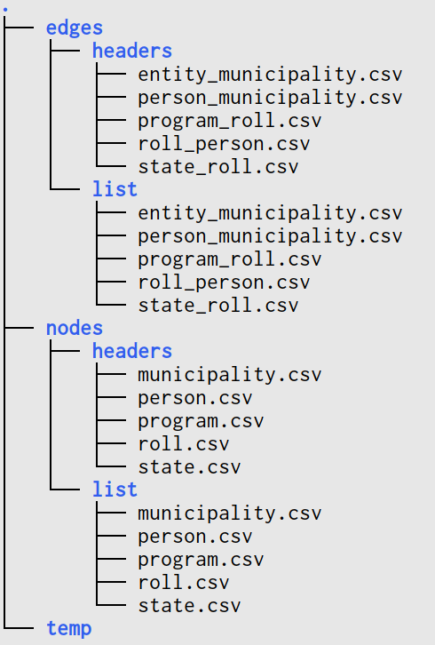

Como podemos ver, estamos separando los datos de los nodos y las relaciones que hay entre ellos. En las carpetas de *headers* se guardarán CSV con el mismo número de columnas que los correspondientes a las carpetas *list* que es donde se guardará la información. Los *headers* hace referencia a los nombres que va a tener cada entidad y sus propiedades. Podemos ver lo que contiene cada uno de los archivos de la siguiente manera:

```bash
for file in ./nodes/headers/*.csv; do
    cat <(echo "$file") <(head -1 "$file") <(echo "\n")
done
```

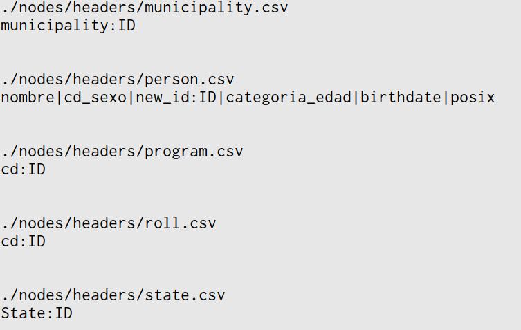

Para las aristas:

```bash
for file in ./edges/headers/*.csv; do
    cat <(echo "$file") <(head -1 "$file") <(echo "\n")
done
```

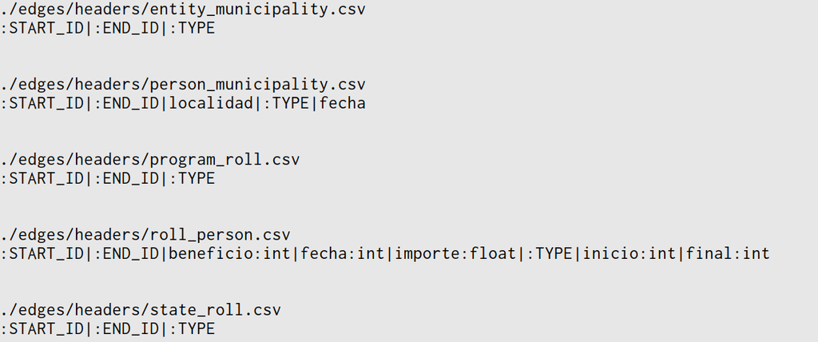

Podemos observar que en las relaciones se usaron más propiedades, los identificadores del nodo de inicio al nodo de destino, el tipo de relación entre agentes y las que necesitemos agregar así como el tipo de dato. Podemos ver que tenemos propiedades como fechas en números, así como importes y beneficios. Todas estas propiedades se verán reflejadas en la base de datos.

Una vez que tenemos toda nuestra información guardada en la estructura deseada procedemos a crear la base de datos. Para ello necesitamos un archivo con el comando que lo haga:

```bash
#! /usr/bin/env bash

export NODEH=./data/nodes/headers
export NODEL=./data/nodes/list
export EDGEH=./data/edges/headers
export EDGEL=./data/edges/list
/var/lib/neo4j/bin/neo4j-admin import --mode=csv --delimiter="|" \
    --database=nominal.db \
    --ignore-duplicate-nodes=true \
    --nodes:person "$NODEH/person.csv,$NODEL/person.csv" \
    --nodes:state "$NODEH/state.csv,$NODEL/state.csv" \
    --nodes:municipality "$NODEH/municipality.csv,$NODEL/municipality.csv" \
    --nodes:program "$NODEH/program.csv,$NODEL/program.csv" \
    --nodes:roll "$NODEH/roll.csv,$NODEL/roll.csv" \
    --relationships "$EDGEH/roll_person.csv,$EDGEL/roll_person.csv" \
    --relationships "$EDGEH/program_roll.csv,$EDGEL/program_roll.csv" \
    --relationships "$EDGEH/entity_municipality.csv,$EDGEL/entity_municipality.csv" \
    --relationships "$EDGEH/state_roll.csv,$EDGEL/state_roll.csv" \
    --relationships "$EDGEH/person_municipality.csv,$EDGEL/person_municipality.csv" \
```

Lo que estamos haciendo aquí es usar el administrador de importación de datos de Neo4j que es la manera más eficiente de hacer una carga de datos masivos, se le está haciendo saber que están en forma de CSV delimitados por el símbolo ‘|’ y que debe importarlos a una base de datos de nombre “nominal.db” así como que no importe nodos repetidos. Posteriormente se le hace saber qué tipo de contenido tiene cada archivo. El administrador de Neo4j paraleliza la tarea y utiliza la memoria disponible de manera eficiente. Si los datos que se tienen son muy grandes, esta es la manera de ingresarlos. Cabe destacar que esto sirve específicamente para la última versión de Neo4j (3.3.0) pues en las versiones anteriores aún no está completa la funcionalidad de “neo4j-admin” pero existe la herramienta *neo4j-import* que ya se encuentra descontinuada en la versión actual.

[figure not shown]

Finalmente se necesita la receta para crear el contenedor de Docker que se escribe en un archivo llamado **Dockerfile**:

```bash
from ollin18/senate_base_ubuntu

MAINTAINER Ollin Demian Langle Chimal <ollin.langle@ciencias.unam.mx>

ENV REFRESHED_AT 2017-11-03

ADD http://dist.neo4j.org/neo4j-community-3.3.0-unix.tar.gz /var/lib
RUN tar -xzvf /var/lib/neo4j-community-3.3.0-unix.tar.gz
RUN mv /var/lib/neo4j-* /var/lib/neo4j

ADD create_db.sh create_db.sh
COPY data data

RUN bash create_db.sh

ADD http://dist.neo4j.org/jexp/shell/neo4j-shell-tools_3.0.1.zip  /var/lib/neo4j/lib

RUN yes | unzip /var/lib/neo4j/lib/neo4j-shell-tools_3.0.1.zip -d /var/lib/neo4j/lib && rm /var/lib/neo4j/lib/*.zip

RUN chmod +x /var/lib/neo4j/lib/*.jar

WORKDIR /var/lib/neo4j

RUN wget https://github.com/neo4j-contrib/neo4j-apoc-procedures/releases/download/3.3.0.1/apoc-3.3.0.1-all.jar --directory-prefix=plugins

RUN mkdir graphml

VOLUME /data

COPY docker-entrypoint.sh /tmp/docker-entrypoint.sh
EXPOSE 7475 7473 7687

ENTRYPOINT ["/tmp/docker-entrypoint.sh"]

CMD ["neo4j"]
```

# Usando la base de datos

Lo que hace este archivo es descargar todos los archivos necesarios de internet a nuestro contenedor así como los archivos que tenemos en local y como una computadora instalará y ejecutará todo lo que sea necesario. Para dar esta instrucción es necesario ejecutar el siguiente comando en shell:

```bash
docker build --tag neo_nominal:0.1 --tag neo_nominal:latest .
```

Esto va a crear un contenedor con las instrucciones dadas en el *Dockerfile* y lo llamará *neo_nominal*, y para acceder a él sólo ejecutamos lo siguiente:

```bash
docker run \
--publish=7475:7475 --publish=7476:7476\
--volume=$HOME/data:/data/ \
--volume=$HOME/neo4j/logs:/logs --env=NEO4J_AUTH=none\
--env=NEO4J_dbms_active_database="nominal.db"\
neo_nominal
```

Esto hará que el contenedor *corra* y se conecten los puertos del mismo con los de nuestra computadora para poder acceder a la información de nuestra base de datos. Ahora podemos conectar nuestra base de datos con un lenguaje de programación para analisar los datos o acceder a la GUI de Neo4j por medio de un navegador.

Si tomamos en cuenta un mapa general de nuestra base de datos, esta se ve así:

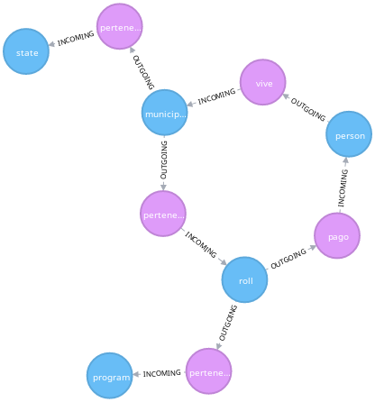

## Respondiendo preguntas

Utilizando el lenguaje *R* y el paquete *RNeo4j* podemos obtener los datos para analizarlos.

Una pregunta que nos podemos hacer ¿Qué persona ha recibido más pagos y por parte de qué padrón? lo cual se responde con un simple *query*:

```r
query="match (p:person)<-[]-(r:roll)
unwind p.new_id as quien
return quien as Persona, count(quien) as Veces, r.cd as Padron order by Veces desc limit 5"
cypher(graph,query)
```

```
##    Persona Veces Padron
## 1 62034967    10   0010
## 2 30813336    10   0010
## 3 29958423    10   0010
## 4 39422879    10   0010
## 5 61563971    10   0010
```

Si queremos saber qué Estado es el que cuenta con más personas apoyadas

```r
query="match (s:state)<-[*1..2]-(p:person)
unwind s.State as Estado
return distinct Estado as Estado, count(*) as Personas order by Personas desc limit 5"
cypher(graph,query)
```

```
##   Estado Personas
## 1     28   219569
## 2     12    46999
## 3     03    45407
## 4     07    43959
## 5     20    37130
```

Entonces nos gustaría saber de qué tamaño es la población de personas que reciben alguna ayuda:

```r
query="match (p:person)
return count(p)"
cypher(graph,query)
```

```
##   count(p)
## 1   250486
```

Finalmente observemos una visualización de una pequeña muestra de los datos

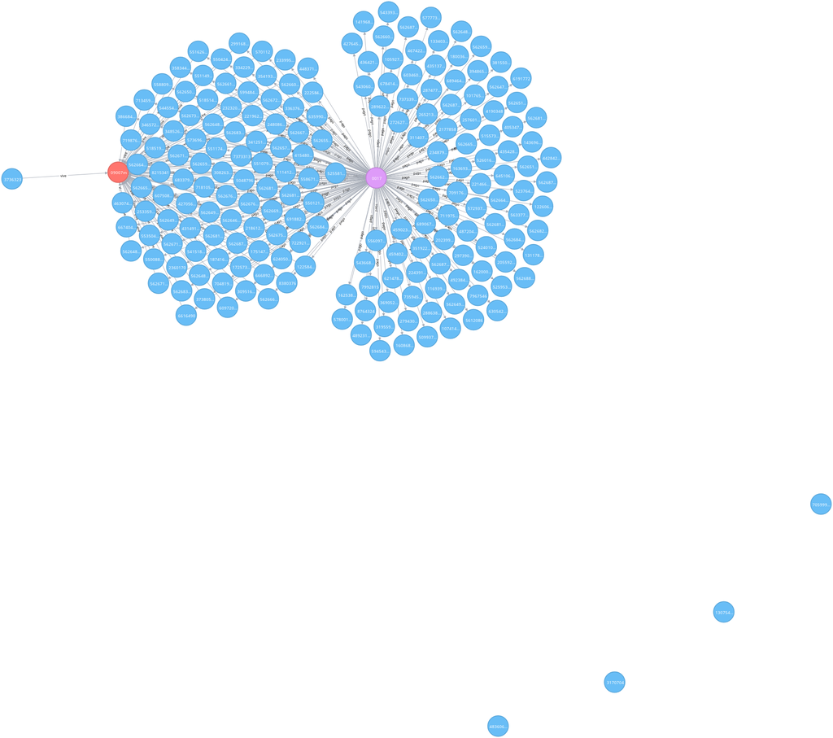

En próximas entradas discutiremos más funcionalidades de la base de datos así como el manejo y análisis de los datos.